# Communicate Data Funding ( USA YouTube dataset)

## The top 15 views of video

#### The best indicator for virality would be the counting on views.

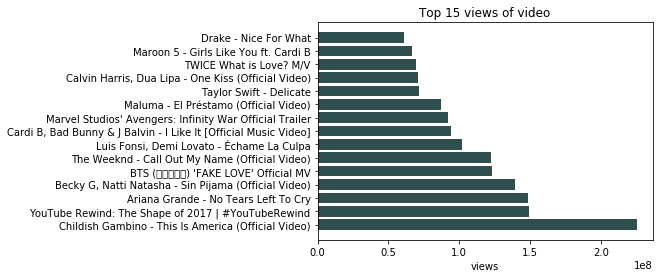

```python
top10(youtube, 'views', 15)
```

#### Till now, This Is America has 479 million views, 7.6m likes, 579k dislikes

## Top 15 comments of video

#### Comments could be positive, negative and neutral, so it can’t help to decide the popularity pretty much. However, I believe comments reflects views.

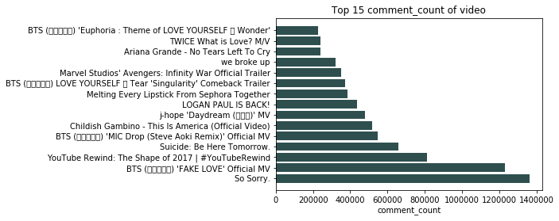

```python
top10(youtube, 'comment_count', 15)
```

## Top 15 likes of video

#### Along with views, we could conclude if the video is popular or not.

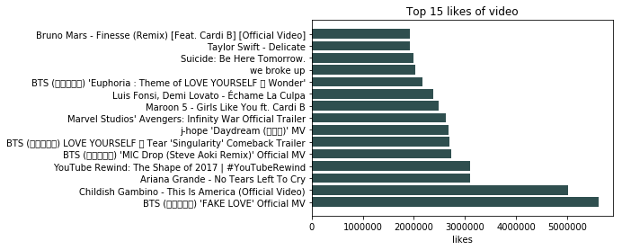

```python
top10(youtube, 'likes', 15)
```

## Top 15 dislikes of video

#### I believe only first two videos are truely hated by audiences. Others are due to the highly viewed by people, since dislikes and views are correlated.

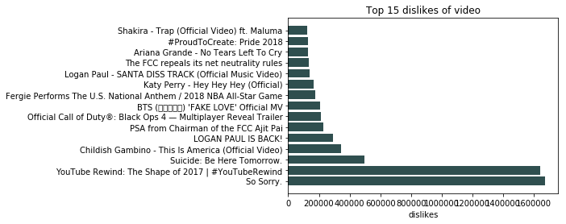

```python
top10(youtube, 'dislikes', 15)
```

## The impact of views on liks vs. dislikes

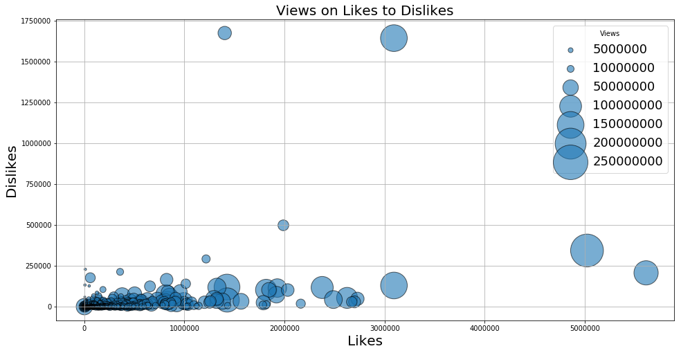

```python
plt.figure(figsize = (16,8))
plt.grid()
plt.scatter(data = youtube, x = 'likes', y = 'dislikes', s = youtube['views']/100000, edgecolors='black', alpha = 0.6)
plt.title('Views on Likes to Dislikes', fontsize = 20)
plt.xlabel('Likes', fontsize = 20)
plt.ylabel('Dislikes', fontsize = 20)


size = [5000000, 10000000, 50000000, 100000000, 150000000, 200000000, 250000000]
col = sns.color_palette()[0]
leg_obj = []
for s in size:
    leg_obj.append(plt.scatter([],[], s=s/100000, color = col, alpha = 0.6, edgecolors='black'))
plt.legend(leg_obj, size, title = 'Views',prop= {'size': 18})
```

## Count on category

#### The bars show number of each category, orderder from most to least.

```
Text(0.5,0,'Categoty')
```

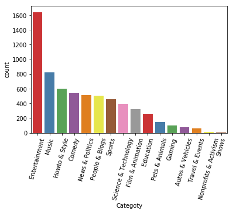

```python
sns.countplot(data = youtube, x = 'category', palette = 'Set1', order = ['Entertainment', 'Music','Howto & Style','Comedy','News & Politics','People & Blogs','Sports','Science & Technology','Film & Animation','Education','Pets & Animals','Gaming','Autos & Vehicles','Travel & Events','Nonprofits & Activism', 'Shows'])
plt.xticks(rotation = 75)
plt.xlabel('Categoty')
```

## Heatmap of trending duration on different category

#### Besides the number of videos, the trending time of the video is also an important indicator to its popularity.

```python
duration = youtube_df['title'].value_counts().to_frame()
duration = duration.reset_index()
duration.columns = ['title', 'trending_duration']
duration.head()
```

|  | title | trending_duration |
| --- | --- | --- |
| 0 | WE MADE OUR MOM CRY...HER DREAM CAME TRUE! | 30 |
| 1 | Why I'm So Scared (being myself and crying too... | 29 |
| 2 | The ULTIMATE $30,000 Gaming PC Setup | 29 |
| 3 | Charlie Puth - BOY [Official Audio] | 29 |
| 4 | Mission: Impossible - Fallout (2018) - Officia... | 29 |

```
Text(0.5,1,'Trending duration on Category')
```

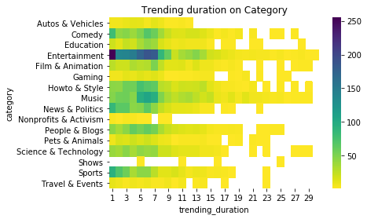

```python
youtube= pd.merge(youtube, duration, on = 'title')
sns.heatmap(youtube.groupby(['category','trending_duration']).count()['video_id'].unstack(), cmap = 'viridis_r')
plt.title('Trending duration on Category')
```

## Entertainment WordCloud

#### We pick most 100 frequent words, larger size for more frequent word.

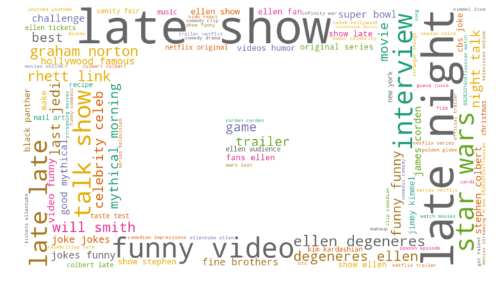

```python
tags = youtube[youtube['category'] == 'Entertainment']['tags'].str.lower().str.cat(sep = ' ')
wc(tags)
```

## Music WordCloud

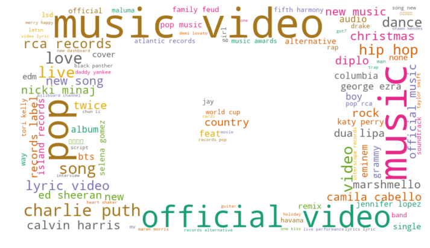

```python
tags = youtube[youtube['category'] == 'Music']['tags'].str.lower().str.cat(sep = ' ')
wc(tags)
```

## Howto & Style WordCloud

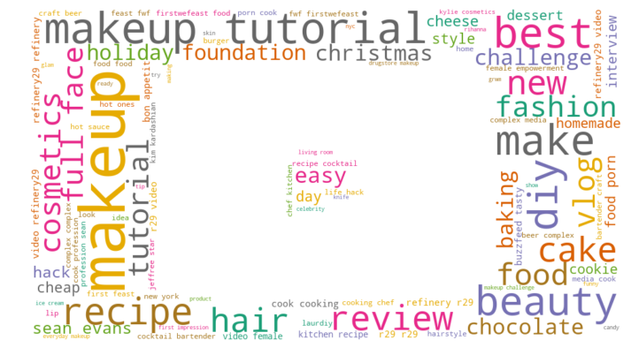

```python
tags = youtube[youtube['category'] == 'Howto & Style']['tags'].str.lower().str.cat(sep = ' ')
wc(tags)
```

## Comedy WordCloud

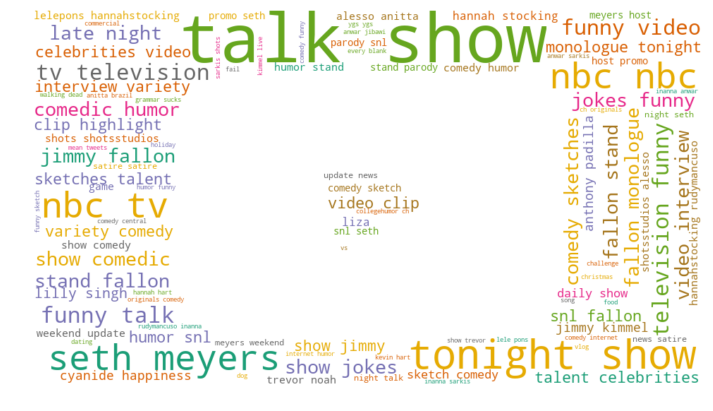

```python
tags = youtube[youtube['category'] == 'Comedy']['tags'].str.lower().str.cat(sep = ' ')
wc(tags)
```

## Audiences’ reflection delivered by views, likes, dislikes, comments. Here I apply boxplot, which is meaningful when one is categorical variable, the other is numeric variable.

## Displaying views(log) distribution by category

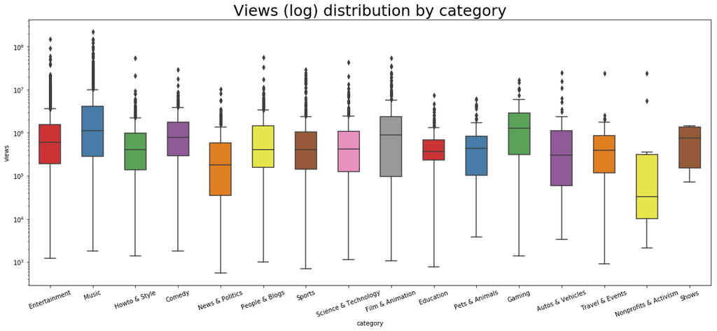

```python
plt.figure(figsize = (20,8))
plt.title('Views (log) distribution by category', fontsize = 25)
plt.yscale('log')
plt.xticks(rotation=20)
sns.boxplot(x='category',y='views',data=youtube, width=0.5,palette='Set1', order = ['Entertainment', 'Music','Howto & Style','Comedy','News & Politics','People & Blogs','Sports','Science & Technology','Film & Animation','Education','Pets & Animals','Gaming','Autos & Vehicles','Travel & Events','Nonprofits & Activism', 'Shows'])
```

## Displaying likes(log) distribution by category

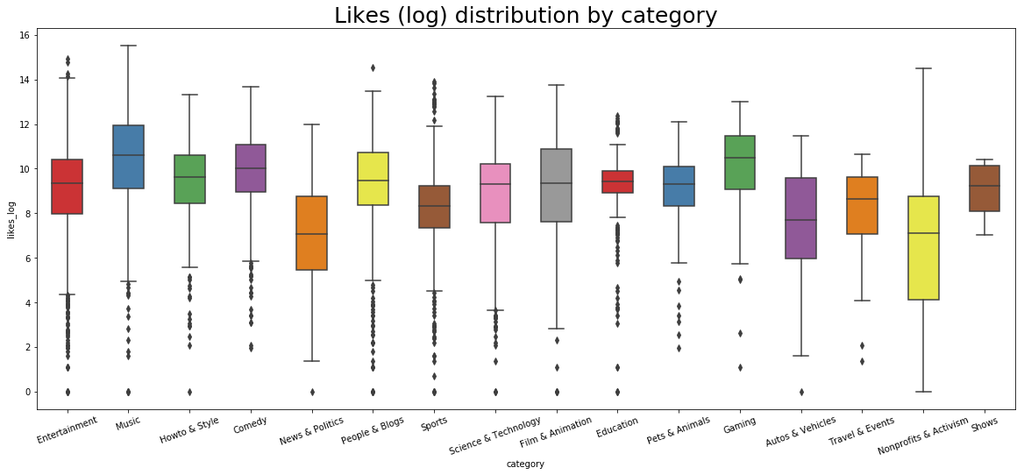

```python
youtube['likes_log'] = np.log(youtube['likes']+1)

plt.figure(figsize = (20,8))
plt.title('Likes (log) distribution by category', fontsize = 25)
plt.xticks(rotation=20)
sns.boxplot(x='category',y='likes_log',data=youtube, width=0.5,palette='Set1', order = ['Entertainment', 'Music','Howto & Style','Comedy','News & Politics','People & Blogs','Sports','Science & Technology','Film & Animation','Education','Pets & Animals','Gaming','Autos & Vehicles','Travel & Events','Nonprofits & Activism', 'Shows'])
```

## Displaying dislikes(log) distribution by category

#### Dislikes don't get influenced by category either.

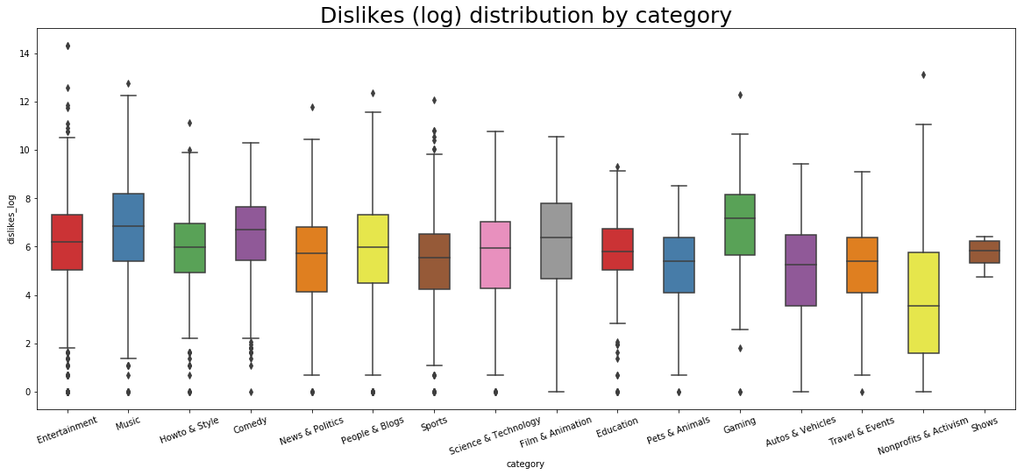

```python
youtube['dislikes_log'] = np.log(youtube['dislikes'] + 1)

plt.figure(figsize = (20,8))
plt.title('Dislikes (log) distribution by category', fontsize = 25)
plt.xticks(rotation=20)
sns.boxplot(x='category',y='dislikes_log',data=youtube, width=0.5,palette='Set1', order = ['Entertainment', 'Music','Howto & Style','Comedy','News & Politics','People & Blogs','Sports','Science & Technology','Film & Animation','Education','Pets & Animals','Gaming','Autos & Vehicles','Travel & Events','Nonprofits & Activism', 'Shows'])
```

## Displaying comments(log) distribution by category

#### Comments don't get influenced by category either.

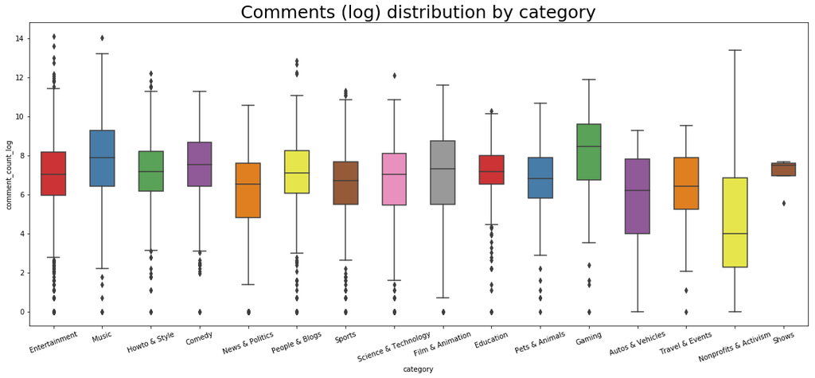

```python
youtube['comment_count_log'] = np.log(youtube['comment_count'] + 1)

plt.figure(figsize = (20,8))
plt.title('Comments (log) distribution by category', fontsize = 25)
plt.xticks(rotation=20)
sns.boxplot(x='category',y='comment_count_log',data=youtube, width=0.5,palette='Set1', order = ['Entertainment', 'Music','Howto & Style','Comedy','News & Politics','People & Blogs','Sports','Science & Technology','Film & Animation','Education','Pets & Animals','Gaming','Autos & Vehicles','Travel & Events','Nonprofits & Activism', 'Shows'])
```

## Rate distribution

#### Here's a combination rate distribution for views, likes, dislikes, comments. All of four are bell-shaped, which is normal distributed.

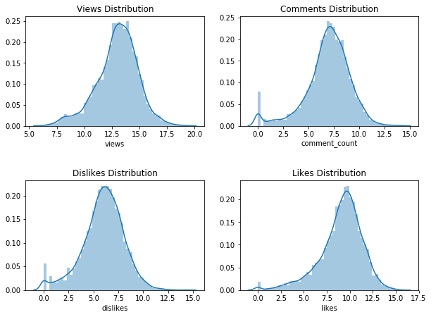

```python
plt.figure(figsize=(10,8))

plt.subplot(221)
sns.distplot(np.log(youtube['views']+1))
plt.title('Views Distribution',fontsize=12)

plt.subplot(222)
sns.distplot(np.log(youtube['comment_count']+1))
plt.title('Comments Distribution', fontsize=12)

plt.subplot(223)
sns.distplot(np.log(youtube['dislikes']+1))
plt.title('Dislikes Distribution', fontsize=12)

plt.subplot(224)
sns.distplot(np.log(youtube['likes']+1))
plt.title('Likes Distribution', fontsize=12)

plt.subplots_adjust(wspace = 0.2, hspace = 0.5,top = 0.8)
```

## Relationship between each variables (views, likes, dislikes, comments)

#### 1) likes and views are highly correlated

#### 2) likes and comments are highly correlated

#### 3) comments and views are moderately correlated

#### 4) dislikes and views are low correlated

#### 5) dislikes and likes are low correlated

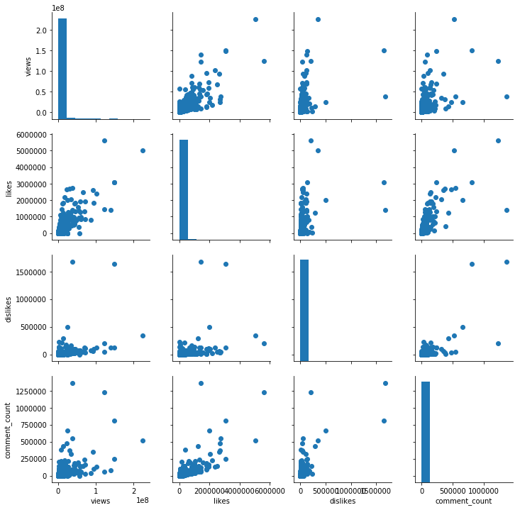

```python
youtube_stat = ['views', 'likes', 'dislikes', 'comment_count']
g = sns.PairGrid(data = youtube, vars = youtube_stat, )
g = g.map_offdiag(plt.scatter)
g.map_diag(plt.hist)
```

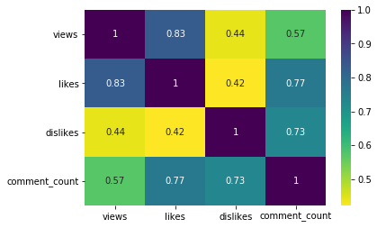

```python
sns.heatmap(youtube[['views', 'likes', 'dislikes', 'comment_count']].corr(), annot=True, cmap = 'viridis_r')
```

## Most influenced publisher

#### I define the influenced channel by if the videos they published are over 40. There are only 12 channels with published videos more than 40, out of 2199 channels.

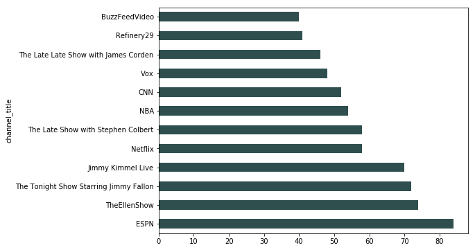

```python
top_publisher = publisher[publisher['video_id']>=40]
top_publisher.plot(kind = 'barh',legend=False, color='darkslategrey',figsize=(8,6))
```

## BEST time to publish

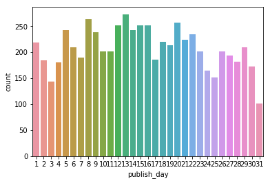

```python
sns.countplot(data = youtube, x = 'publish_day')
```

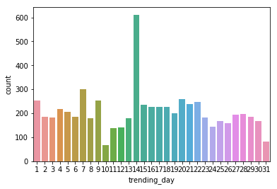

```python
sns.countplot(data = youtube, x = 'trending_day')
```

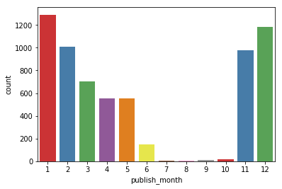

```python
sns.countplot(data = youtube, x = 'publish_month', palette='Set1')
```

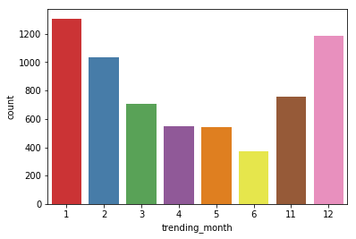

```python
sns.countplot(data = youtube, x = 'trending_month',palette='Set1')
```

## Conclusion

#### The best publish time for a youtuber would be winter, either day, while better before 15th.